# Yelp - EDA

Ertuğrul Ural

16 05 2019

## Load Libraries

```r
#Load pacman package and p_load function installs missing packages and loads all the packages given as input
if (!require("pacman")) install.packages("pacman")

pacman::p_load("tidyverse",   #data manipulation and graphs
               "lubridate",   #date manipulation
               "stringr",     #string manipulation
               "wordcloud",   #wordcloud
               "tidytext",    #tidy implementation of NLP methods
               "leaflet",     #maps
               "igraph" ,     #graphs
               "ggraph",      #graphs
               "tm",          #for general text mining functions
               "SnowballC",   #for stemming
               "data.table",  #for efficiency of Importing Large CSV files
               "textcat")     #for language detection
```

1. Introduction
2. Overview of Business and Reviews dataframes
3. Number of Cities in Yelp Dataset
4. Most Popular Categories
5. Distribution of stars given by the users
6. Most Popular Categories
7. Top 20 cities with the largest number of restaurants
8. Most popular five cuisines in top 5 cities
9. Map of the Restaurants in Toronto
10. Most Appreciated Restaurants in Toronto
- 10.0 “Pai Northern Thai Kitchen”
- 10.1 Wordcloud of the reviews of “Pai Northern Thai Kitchen”
- 10.2 Sentiment Analysis - Postive and Not So Postive Words of “Pai Northern Thai Kitchen”
- 10.3 Calculate Sentiment for the reviews
- 10.4 Top 5 Negative Reviews
- 10.5 Top 5 Positive Reviews
- 10.6 Most Common Bigrams of “Pai Northern Thai Kitchen”
- 10.7 Relationship among words
11. Highly criticized restaurants in Toronto
- 11.0 “Toula Restaurant & Bar”
- 11.1 Word Cloud of the reviews of “Toula Restaurant & Bar”
- 11.2 Sentiment Analysis - Postive and Not So Postive Words of “Toula Restaurant & Bar”
- 11.3 Calculate Sentiment for the reviews
- 11.4 Top 5 Negative Reviews of “Toula Restaurant & Bar”
- 11.5 Top 5 Positive Reviews “Toula Restaurant & Bar”
- 11.6 Most Common Bigrams of “Toula Restaurant & Bar”
- 11.7 Relationship among words in “Toula Restaurant & Bar”
12. Proportion of closed restaurants types in Toronto
- 12.1 The most negative comments among the closed restaurants
- 12.2 Locations of the Open/Closed Restaurants in Toronto Map
- 12.3 An interactive map of restaurants in Toronto with their average ratings
- 12.4 The reviews given by customer for closed restaurants in Toronto related to food, service, ambience and staff
- 12.5 Word Cloud of the reviews of Watermark Irish Pub
- 12.6 Sentiment Analysis - Postive and Not So Postive Words of “Watermark Irish Pub”
- 12.7 Calculate Sentiment for the reviews of “Watermark Irish Pub”
- 12.8 Top 5 Negative Reviews of “Watermark Irish Pub”

## Load Data

```r
business <- fread("~/yelp_business.csv", header = T, sep = ',')
review <- fread("~/yelp_review.csv", header = T, sep = ',')
```

#### The Yelp dataset is downloaded from https://www.yelp.com/dataset/challenge. In total, there are 5,261,668 user reviews, information on 174,567 business. we will focus on two tables which are business and review datasets.

#### Attributes of business table are as following:

- business_id: ID of the business
- name: name of the business
- neighborhood: neighborhood of the business
- address: address of the business
- city: city of the business
- state: state of the business
- postal_code: postal code of the business
- latitude: latitude of the business
- longitude: longitude of the business
- stars: average rating of the business
- review_count: number of reviews received
- is_open: 1 if the business is open, 0 otherwise
- categories: multiple categories of the business

#### Attribues of review table are as following:

- review_id: ID of the review
- user_id: ID of the user
- business_id: ID of the business
- stars: ratings of the business
- date: review date
- text: review from the user
- useful: number of users who vote a review as usefull
- funny: number of users who vote a review as funny
- cool: number of users who vote a review as cool

## Overview of Business and Reviews dataframes

```r
head(business)
str(business)
glimpse(business)
summary(business)

head(review)
str(review)
glimpse(review)
summary(review)
```

## Number of Cities in Yelp Dataset

Las Vegas, Phoenix and Toronto seem to be most favorite cities in Yelp dataset.

```r
business$city=business$city %>%
  as.factor

business$city%>%
  summary
```

```
##         Las Vegas           Phoenix           Toronto         Charlotte
##             26775             17213             17206              8553
##        Scottsdale        Pittsburgh              Mesa         MontrÃ©al
##              8228              6355              5760              5709
##         Henderson             Tempe          Chandler         Edinburgh
##              4465              4263              3994              3868
##         Cleveland           Madison          Glendale           Gilbert
##              3322              3213              3206              3128
##       Mississauga         Stuttgart            Peoria           Markham
##              2726              2000              1706              1564
##   North Las Vegas         Champaign       Scarborough        North York
##              1393              1195              1095              1092
##          Surprise     Richmond Hill           Concord          Brampton
##              1018               888               864               839
##          Goodyear           Vaughan         Etobicoke          Matthews
##               772               768               697               666
##          Oakville          Avondale      Huntersville         Fort Mill
##               660               628               566               559
##          Lakewood          Gastonia         Cornelius            Mentor
##               487               438               428               407
##            Urbana        Cave Creek       Monroeville     North Olmsted
##               384               372               360               351
##         Thornhill          Westlake      Strongsville            Whitby
##               346               346               338               335
##             Laval         Middleton    Fountain Hills         Pineville
##               332               331               320               313
##    Cuyahoga Falls            Aurora         Newmarket            Medina
##               310               301               294               289
##         Pickering      Boulder City         Beachwood          Montreal
##               283               269               265               264
##      Indian Trail              Kent           Wexford              Ajax
##               256               256               255               252
##             Parma       Rocky River        Willoughby       Sun Prairie
##               244               238               225               222
##          Sun City   Litchfield Park        Woodbridge              Stow
##               217               207               206               204
##              Avon         Fitchburg Cleveland Heights       Ludwigsburg
##               200               195               191               191
##             Solon            Hudson         Inverness            Verona
##               190               187               177               176
##       Bethel Park     Chagrin Falls       Bridgeville        Coraopolis
##               174               170               169               162
##            Elyria         Brunswick        Kannapolis        Canonsburg
##               162               156               154               153
##            Waxhaw          Brossard          Fairlawn  Mayfield Heights
##               151               147               144               143
##           Chester         East York           Belmont            Verdun
##               141               141               139               138
##          Tolleson    North Royalton            Monona           (Other)
##               132               131               130             12324
```

## Most Popular Categories

The most popular categories of business are plotted in the bar plot

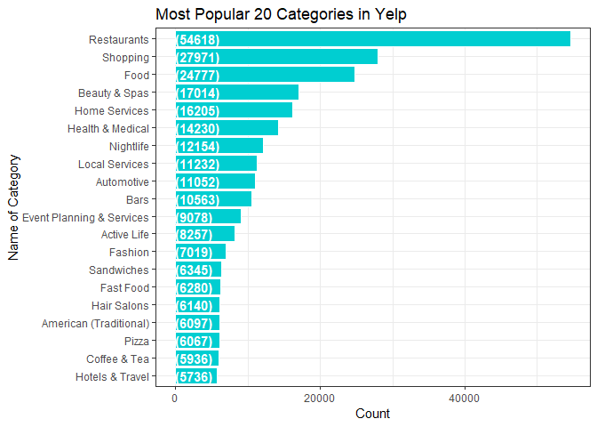

### I am only interested in restaurants for my further analysis. So let’s remove all other businesses.

```r
business <- business %>%
  mutate(rest = ifelse(grepl('Restaurants',categories), 1, 0)) %>%
  filter(rest == 1)
```

### Let’s look at the distribution of stars given by the users.

The distribution of ratings is considerably skewed, there are a lot more 4 and 5 star ratings than 1,2 and 3. we could say that people seem to review things they like. In general, people seem to be more likely to write a review for a positive experience than a negative one.

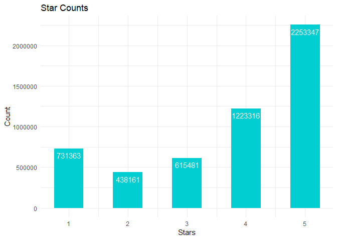

### Top 20 cities with the largest number of restaurants

We show the Top 20 cities which has the most number of restaurants mentioned in Yelp. Toronto, Las Vegas and Phoenix.

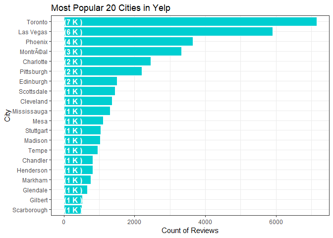

### Most popular five cuisines in top 5 cities

[output not shown]

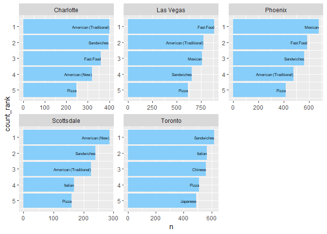

### Map of the Restaurants in Toronto

Since in Yelp dataset the largest number of restaurants are in Toronto,that’s why I wanted to continue analysis with Toronto.

[interactive chart not shown]

### Most Appreciated Restaurants in Toronto

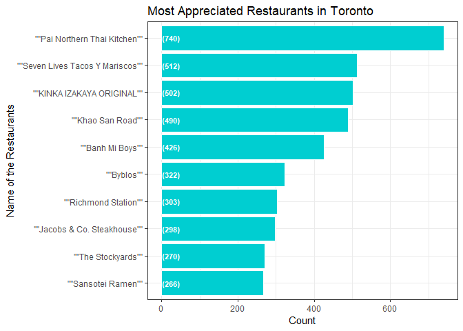

```r
BestReviews = review %>%
  filter(stars == 5) %>%
  group_by(business_id) %>%
  summarise(Count = n()) %>%
  arrange(desc(Count)) %>%
  ungroup() %>%
  mutate(BusinessID = reorder(business_id,Count))

BestReviews = inner_join(BestReviews, business, by = "business_id")

BestReviews_Toronto <- BestReviews %>%
  filter(city == "Toronto") %>%
  head(10)

BestReviews_Toronto %>%
  mutate(name = reorder(name,Count)) %>%
  ggplot(aes(x = name,y = Count)) +
  geom_bar(stat='identity',colour="white", fill = "#00CED1") +
  geom_text(aes(x = name, y = 1, label = paste0("(",Count,")",sep="")),
            hjust=0, vjust=.5, size = 3, colour = 'white',
            fontface = 'bold') +
  labs(x = 'Name of the Restaurants',
       y = 'Count',
       title = 'Most Appreciated Restaurants in Toronto') +
  coord_flip() +
  theme_bw()
```

### Wordcloud of the reviews of Pai Northern Thai Kitchen

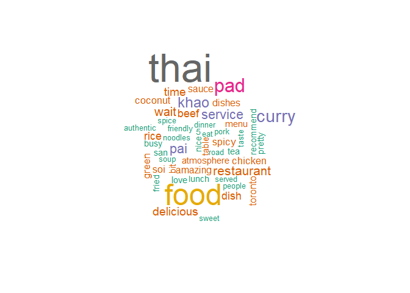

```r
createWordCloud = function(train)
{
  train %>%
  unnest_tokens(word, text) %>%
  filter(!word %in% stop_words$word) %>%
  count(word,sort = TRUE) %>%
  ungroup()  %>%
  head(50) %>%

  with(wordcloud(word, n, max.words = 50,colors=brewer.pal(8, "Dark2")))
}

#Pai Northern Thai Kitchen
createWordCloud(review %>%
  filter(business_id == "r_BrIgzYcwo1NAuG9dLbpg"))
```

## Sentiment Analysis - Postive and Not So Postive Words of “Pai Northern Thai Kitchen”

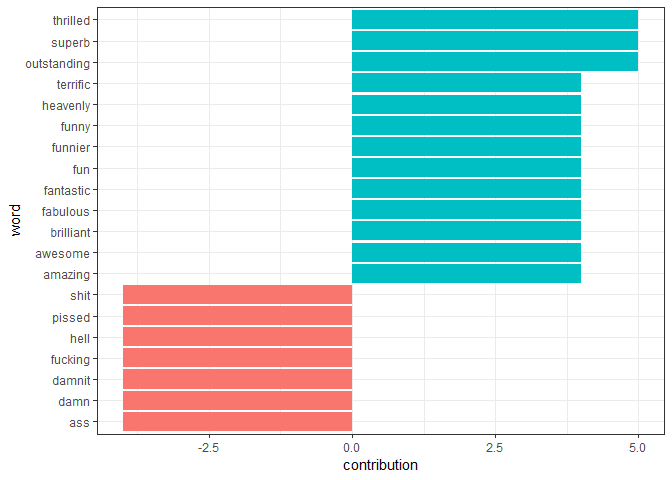

```r
positiveWordsBarGraph <- function(SC) {
  contributions <- SC %>%
    unnest_tokens(word, text) %>%
    count(word,sort = TRUE) %>%
    ungroup() %>%

    inner_join(get_sentiments("afinn"), by = "word") %>%
    group_by(word) %>%
    summarize(occurences = n(),
              contribution = sum(score))

  contributions %>%
    top_n(20, abs(contribution)) %>%
    mutate(word = reorder(word, contribution)) %>%
    head(20) %>%
    ggplot(aes(word, contribution, fill = contribution > 0)) +
    geom_col(show.legend = FALSE) +
    coord_flip() + theme_bw()
}

positiveWordsBarGraph(review %>%
                        filter(business_id == "r_BrIgzYcwo1NAuG9dLbpg"))
```

### Calculate Sentiment for the reviews of Pai Northern Thai Kitchen

```r
Pai_Northern_Thai_reviews = review %>%
  filter(business_id == "r_BrIgzYcwo1NAuG9dLbpg")

calculate_sentiment <- function(review_text)
{
  sentiment_lines  =  review_text %>%
                  filter(textcat(text) == "english") %>%  # considering only English text
                  unnest_tokens(word, text) %>%
                  inner_join(get_sentiments("afinn"), by = "word") %>%
                  group_by(review_id) %>%
                  summarize(sentiment = mean(score),words = n()) %>%
                  ungroup() %>%
                  filter(words >= 5)

  return(sentiment_lines)

}

sentiment_lines = calculate_sentiment(Pai_Northern_Thai_reviews)

head(sentiment_lines)
```

```
## # A tibble: 6 x 3
##   review_id              sentiment words
##   <chr>                      <dbl> <int>
## 1 -2GbHgsOQEoTyYE1FZF_Eg      2.4      5
## 2 -5HQRuCjLea87U6CbgFDhQ      2.8      5
## 3 -cFyhgRpW_JE23rXb7IFIw      2.17     6
## 4 -g96p2T6f9JNjxjVNLHIug      3        5
## 5 -gL10Yxv5G9al04jTGANCQ      2.3     10
## 6 -WASaxgdFuhIWjAlwItmjQ      2.12     8
```

### Let’s examine the top 5 most negative reviews.

Slow service, overpriced, uncomfortable chairs, the atmosphere is incredibly dark, crowded and noisy

```r
display_neg_sentiments <- function(sentiment_lines,review_text)
{
  neg_sentiment_lines = sentiment_lines %>%
  arrange(desc(sentiment))  %>%
  top_n(-5, sentiment) %>%
  inner_join(review_text, by = "review_id") %>%
  select(date,sentiment,text)

head(neg_sentiment_lines$text)

}

display_neg_sentiments(sentiment_lines,Pai_Northern_Thai_reviews)
```

```
## [1] "Save the money and time you would've spent here and take yourself down the block to Khao San Road. I had ordered the Pad Thai to go because a 45 minute wait seemed high unappealing. I started to eat it within of 5 minutes of receiving it and I was shocked. The taste was EXTREMELY weak and un…
## [2] "Never coming back again! Here' why:\n1. extremely slow service - took over 15mins for our drinks to arrive, another 20 mins later 1 extremely small appetizer dish arrived and then another 25-30 mins later the food arrived. That's over an hr of waiting before the main course\n2. bad drinks - …
## [3] "This is probably the worst service I've encountered in Toronto. I wanted to come on a public holiday, because everything else in the neighborhood was closed, and I tried calling several times but no one answered. When I arrived, the hostess gave me the worst attitude, asking, \"\"So do you w…
## [4] "I went with a group of 10 people. They charged me a 20% GRATUITY....but their service was God-awful. They rarely attended our table, It took 55 minutes for our food to arrive. They took our drink orders and did not deliver them. And at the end, they put all of the wrong items on all of our r…
## [5] "This restaurant was crowded and noisy. The tables were packed so closely that I was falling over other diners while maneuvering to my seat.\n\nI ordered spring rolls and pad thai with chicken. The spring rolls were factory. and thoroughly cooked, but the pad thai hurt my eyes.  It hurt my ey…
```

### Let’s examine the top 5 most positive reviews.

Very authentic Thai food, hospitable service, very welcoming and relaxing atmosphere, incredibly helpful staff

```r
display_pos_sentiments <- function(sentiment_lines,review_text)
{
  pos_sentiment_lines = sentiment_lines %>%
  arrange(desc(sentiment))  %>%
  top_n(5, sentiment) %>%
  inner_join(review_text, by = "review_id") %>%
  select(date,sentiment,text)

head(pos_sentiment_lines$text)

}

display_pos_sentiments(sentiment_lines,Pai_Northern_Thai_reviews)
```

```
## [1] "This place was absolutely, mindblowingly AMAZING. So glad I never have to go back to Khao San Road ever again.  Loved the decor, the perfectly spiced green curry served in a carved out coconut and in particular, the mango sticky rice. Very authentic Thai food and wonderful, hospitable servic…
## [2] "Exceeded expectations. I liked the look of the menu online, but when we got here I couldn't wait to go in. The whole restaurant smelled amazing. There was a brilliant buzz about the place and the atmosphere was very welcoming. We had a brilliant experience from start to finish. The waiter wa…
## [3] "Atmosphere was casual and hip, food and drinks were amazing, and service\\/servers were fantastic and very kind. I loved this place. As soon as I walked in I loved the fun and relaxing atmosphere. Our servers were very nice and chatted shortly with us.  Would come back even just for drinks."
## [4] "Amazing food for amazing value - my boyfriend and I absolutely love this place. Props to the chef Nuit Regular for bringing her A-game to this restaurant. If you like Thai food this is the place to go! And if you aren't sure about Thai, try this and you'll learn you love it (most North Ameri…
## [5] "amazing food!  Incredibly helpful staff.  I booked their family style room for a birthday party and they couldn't have been more helpful.  The food was amazing, the staff was amazing, the chef came out to chat with us - they accommodated our many food quirks - really fantastic!  Thank you gu…
```

### Most Common Bigrams of “Pai Northern Thai Kitchen”

```r
count_bigrams <- function(dataset) {
  dataset %>%
    unnest_tokens(bigram, text, token = "ngrams", n = 2) %>%
    separate(bigram, c("word1", "word2"), sep = " ") %>%
    filter(!word1 %in% stop_words$word,
           !word2 %in% stop_words$word) %>%
    count(word1, word2, sort = TRUE)
}

visualize_bigrams <- function(bigrams) {
  set.seed(13)
  a <- grid::arrow(type = "closed", length = unit(.15, "inches"))

  bigrams %>%
    graph_from_data_frame() %>%
    ggraph(layout = "fr") +
    geom_edge_link(aes(edge_alpha = n), show.legend = FALSE, arrow = a) +
    geom_node_point(color = "lightblue", size = 5) +
    geom_node_text(aes(label = name), vjust = 1, hjust = 1) +
    theme_void()

}

visualize_bigrams_individual <- function(bigrams) {
  set.seed(2016)
  a <- grid::arrow(type = "closed", length = unit(.15, "inches"))

  bigrams %>%
    graph_from_data_frame() %>%
    ggraph(layout = "fr") +
    geom_edge_link(aes(edge_alpha = n), show.legend = FALSE, arrow = a,end_cap = circle(.07, 'inches')) +
    geom_node_point(color = "lightblue", size = 5) +
    geom_node_text(aes(label = name), vjust = 1, hjust = 1) +
    theme_void()
}

review %>%
  filter(business_id == "r_BrIgzYcwo1NAuG9dLbpg") %>%
  unnest_tokens(bigram, text, token = "ngrams", n = 2) %>%
  select(bigram,review_id) %>%
  head(10)
```

```
##          bigram              review_id
## 1       we went -2GbHgsOQEoTyYE1FZF_Eg
## 2       went on -2GbHgsOQEoTyYE1FZF_Eg
## 3          on a -2GbHgsOQEoTyYE1FZF_Eg
## 4      a sunday -2GbHgsOQEoTyYE1FZF_Eg
## 5  sunday night -2GbHgsOQEoTyYE1FZF_Eg
## 6      night in -2GbHgsOQEoTyYE1FZF_Eg
## 7        in may -2GbHgsOQEoTyYE1FZF_Eg
## 8      may 2015 -2GbHgsOQEoTyYE1FZF_Eg
## 9      2015 and -2GbHgsOQEoTyYE1FZF_Eg
## 10      and had -2GbHgsOQEoTyYE1FZF_Eg
```

### We can explore the different relationship among the various words in Pai_Northern_Thai reviews here through a network graph

wait ==> time, recommend <== highly,

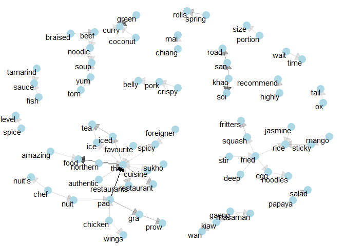

```r
bigrams_Pai_Northern_Thai <- review %>%
  filter(business_id == "r_BrIgzYcwo1NAuG9dLbpg") %>%
  count_bigrams()

bigrams_Pai_Northern_Thai %>%
  filter(n > 25) %>%
  visualize_bigrams()
```

### Highly criticized restaurants in Toronto

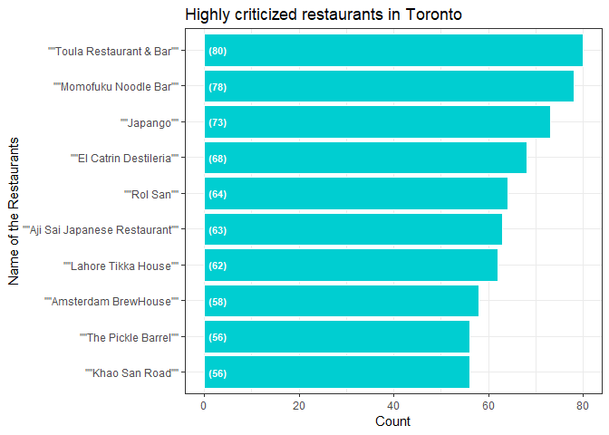

```r
WorstReviews <- review %>%
  filter(stars == 1) %>%
  group_by(business_id) %>%
  summarise(Count = n()) %>%
  arrange(desc(Count)) %>%
  ungroup() %>%
  mutate(BusinessID = reorder(business_id,Count))

WorstReviews = inner_join(WorstReviews, business, by = "business_id")

WorstReviews_Toronto <- WorstReviews %>%
  filter(city == "Toronto") %>%
  head(10)

WorstReviews_Toronto %>%
  mutate(name = reorder(name,Count)) %>%
  ggplot(aes(x = name,y = Count)) +
  geom_bar(stat='identity',colour="white", fill = "#00CED1") +
  geom_text(aes(x = name, y = 1, label = paste0("(",Count,")",sep="")),
            hjust=0, vjust=.5, size = 3, colour = 'white',
            fontface = 'bold') +
  labs(x = 'Name of the Restaurants',
       y = 'Count',
       title = 'Highly criticized restaurants in Toronto') +
  coord_flip() +
  theme_bw()
```

### Wordcloud for the reviews of “Toula Restaurant & Bar”

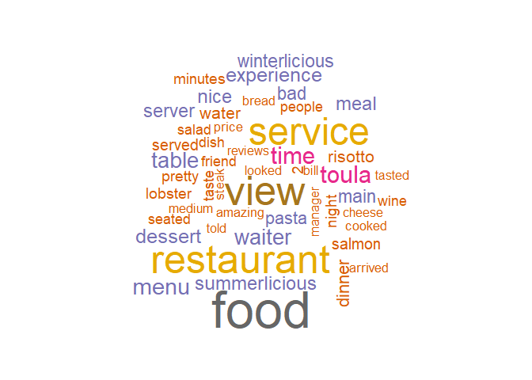

```r
#Toula Restaurant & Bar
createWordCloud(review %>%
  filter(business_id == "jluEI1ZDQDeJlbl-M3YH3Q"))
```

### Sentiment Analysis - Postive and Not So Postive Words of “Toula Restaurant & Bar”

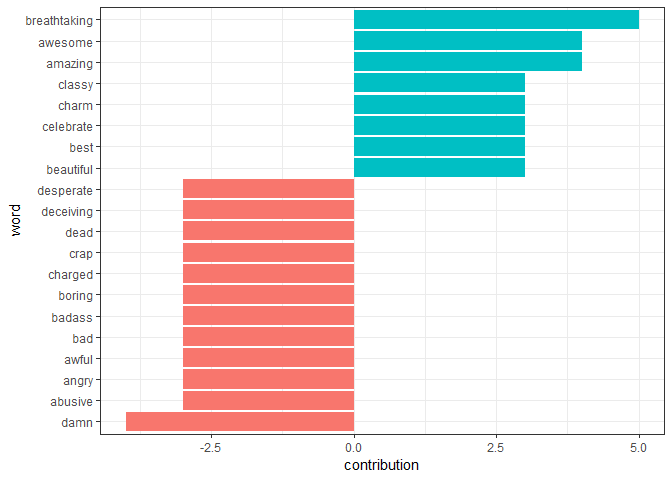

```r
positiveWordsBarGraph <- function(SC) {
  contributions <- SC %>%
    unnest_tokens(word, text) %>%
    count(word,sort = TRUE) %>%
    ungroup() %>%

    inner_join(get_sentiments("afinn"), by = "word") %>%
    group_by(word) %>%
    summarize(occurences = n(),
              contribution = sum(score))

  contributions %>%
    top_n(20, abs(contribution)) %>%
    mutate(word = reorder(word, contribution)) %>%
    head(20) %>%
    ggplot(aes(word, contribution, fill = contribution > 0)) +
    geom_col(show.legend = FALSE) +
    coord_flip() + theme_bw()
}

positiveWordsBarGraph(review %>%
                        filter(business_id == "jluEI1ZDQDeJlbl-M3YH3Q"))
```

### Calculate Sentiment for the reviews of Toula Restaurant & Bar

```r
Toula_Restaurant_reviews = review %>%
  filter(business_id == "jluEI1ZDQDeJlbl-M3YH3Q")

calculate_sentiment <- function(review_text)
{
  sentiment_lines  =  review_text %>%
                  filter(textcat(text) == "english") %>%  # considering only English text
                  unnest_tokens(word, text) %>%
                  inner_join(get_sentiments("afinn"), by = "word") %>%
                  group_by(review_id) %>%
                  summarize(sentiment = mean(score),words = n()) %>%
                  ungroup() %>%
                  filter(words >= 5)

  return(sentiment_lines)

}

sentiment_lines = calculate_sentiment(Toula_Restaurant_reviews)

head(sentiment_lines)
```

```
## # A tibble: 6 x 3
##   review_id              sentiment words
##   <chr>                      <dbl> <int>
## 1 _-j4E6gR8caHBxVScjLcLQ     1.5      10
## 2 _uOy1RgHCue7Hl4CdOSA-g     0.231    13
## 3 02oZNg87bAT0TF_ddS3olQ     1.67      6
## 4 0N2MiMtndFkYlG46EfXngg     1.71     17
## 5 0NpVw0WJUtIGIbDlX7yJ3Q     1.46     13
## 6 1xdGL6R-UtIxNGR-xQLOvA     2.67      6
```

### Let’s examine the top 5 most negative reviews.

Unfriendly staff, expensive and one of the worst meals, Do no waste ur money on this place, aggressive owner and staff, bad service

```r
display_neg_sentiments(sentiment_lines,Toula_Restaurant_reviews)
```

```
## [1] "Worse $30 meal ever!  Went there as a group of 6 for Winterlicious lunch.  Unfriendly staff but if the food was decent we would have overlooked the bad service.  Ordered seafood soup which had drips of liquid and leftover salmon chunks, defrosted calamari, and overboiled pasta.  One spoonful…
## [2] "Horrible. Everything about this dining experience was horrible (except for the view- although it was through a dirty window) and the person I was with.\nThe risotto was raw and swimming in oil. The ravioli  was broken and one big blob. It looked like someone vomited on my plate. \nExpensive …
## [3] "Horrible dining experience. Went once for Winterlicious and another time for the regular menu.  Big mistake.\n\nFor Winterlicious, the food is cold and the plates are all premade that they form hard crusts on the outside (for example on the risotto).  They also have this weird and disgusting…
## [4] "The worst food and service I've ever experienced I've been there for the new year eve 2015 it was a disaster , bad food rotten meat angry and aggressive owner and staff I wish if I could rate it zero"
## [5] "Bad. Bad bad service. We had a reservation but still waited for 1.5 hour. I walked around and noticed only 2\\/3 of the restaurant was filled up. The hostess was an idiot. Food was mediocre. It was Not Fine dining."
```

### Let’s examine the top 5 most positive reviews.

The only pro was the amazing view!, fantastic view, warm service, romantic ambience, pretty good prices, kind and pleasent server.

```r
display_pos_sentiments(sentiment_lines,Toula_Restaurant_reviews)
```

```
## [1] "I went there for Summerlicious last year and the food was definitely not too great.  It didn't taste good at all.  I think I had seafood and my ex had steak... The only pro was the amazing view!\n\nI would suggest it for a drink and the great view!  Other then that, I would recommend going s…
## [2] "We had a great experience at Toula. The view of the restaurant is fantastic, and the service is really warm and helpful. The food was amazing, we had a wonderful night!!"
## [3] "We went there for Winterlicious and got the set menu. Total with tax and tip is $50.\nI have to start by saying the service was excellent. From the hostess, the coat check, and the waitress. We were seated right away by the window. The view is amazing and the ambiance was very romantic. \nWe…
## [4] "The food wasn't amazing but pretty good prices were a bit high but amazing service and got a great view of the city I would defiantly go back soon and would recommend people to go"
## [5] "I came to Toula with a friend and the service here was wonderful! Our server was very kind and pleasant; he kept coming back to make sure we were okay. He made conversation with us, telling us stories and such. \nThe ambiance was nice! The food, however, could be a little better.\nOverall, I…
```

### We can explore the different relationship among the various words in Toula Restaurant & Bar reviews here through a network graph

Service <== bad ==> reviews, amazing ==> view

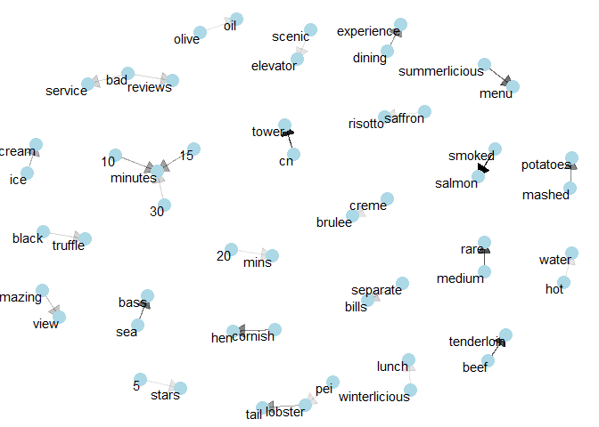

```r
bigrams_Toula_Restaurant <- review %>%
  filter(business_id == "jluEI1ZDQDeJlbl-M3YH3Q") %>%
  count_bigrams()

bigrams_Toula_Restaurant %>%
  filter(n > 5) %>%
  visualize_bigrams()
```

### Proportion of closed restaurants types in Toronto

```r
business %>%
  filter(city == "Toronto") %>%
  group_by(is_open)%>%
  summarise(n=n(), AvgReview = mean(review_count, na.rm = T), AvgStar = mean(stars, na.rm = T)) %>%
  filter(n>50)%>%
  arrange(desc(n)) %>%
  head(20)
```

```
## # A tibble: 2 x 4
##   is_open     n AvgReview AvgStar
##     <int> <int>     <dbl>   <dbl>
## 1       1  4968      51.2    3.44
## 2       0  2180      22.6    3.37
```

```r
business %>%
  filter(city == "Toronto") %>%
  unnest(categories) %>%
  group_by(categories)%>%
  summarise(n=n(), close_prop=sum(is_open==0)/n, open_prop=sum(is_open==1)/n, AvgStar = mean(stars, na.rm = T)) %>%
  filter(n>50)%>%
  arrange(desc(close_prop),desc(n)) %>%
  head(20)
```

```
## # A tibble: 15 x 5
##    categories                 n close_prop open_prop AvgStar
##    <chr>                  <int>      <dbl>     <dbl>   <dbl>
##  1 Japanese;Restaurants      63      0.524     0.476    3.33
##  2 Restaurants;Italian       96      0.5       0.5      3.48
##  3 Restaurants;Burgers       55      0.491     0.509    3.14
##  4 Italian;Restaurants       78      0.474     0.526    3.44
##  5 Restaurants;Chinese      106      0.434     0.566    3.14
##  6 Thai;Restaurants          74      0.432     0.568    3.13
##  7 Restaurants;Sushi Bars    52      0.423     0.577    3.45
##  8 Indian;Restaurants        67      0.418     0.582    3.39
##  9 Restaurants;Thai          55      0.364     0.636    3.02
## 10 Korean;Restaurants        58      0.310     0.690    3.52
## 11 Restaurants;Mexican       56      0.304     0.696    3.31
## 12 Mexican;Restaurants       56      0.286     0.714    3.21
## 13 Chinese;Restaurants      110      0.273     0.727    3.05
## 14 Restaurants;Pizza         79      0.266     0.734    3.06
## 15 Pizza;Restaurants         80      0.262     0.738    3.16
```

### The most negative comments among the closed restaurants

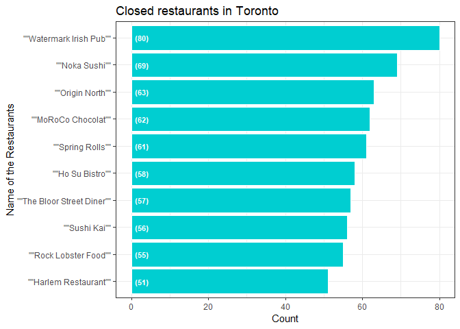

```r
ClosedReviews <- review %>%
  filter(stars < 3) %>%
  group_by(business_id) %>%
  summarise(Count = n()) %>%
  arrange(desc(Count)) %>%
  ungroup() %>%
  mutate(BusinessID = reorder(business_id,Count))

ClosedReviews = inner_join(ClosedReviews, business, by = "business_id")

ClosedReviews_Toronto <- ClosedReviews %>%
  filter(city == "Toronto", is_open == 0) %>%
  head(10)

ClosedReviews_Toronto %>%
  mutate(name = reorder(name,Count)) %>%
  ggplot(aes(x = name,y = Count)) +
  geom_bar(stat='identity',colour="white", fill = "#00CED1") +
  geom_text(aes(x = name, y = 1, label = paste0("(",Count,")",sep="")),
            hjust=0, vjust=.5, size = 3, colour = 'white',
            fontface = 'bold') +
  labs(x = 'Name of the Restaurants',
       y = 'Count',
       title = 'Closed restaurants in Toronto') +
  coord_flip() +
  theme_bw()
```

### Locations of the Open/Closed Restaurants in Map

[interactive chart not shown]

### An interactive map of restaurants in Toronto with their average ratings indicated by color.

[interactive chart not shown]

### For closed restaurants in Toronto the reviews given by customer related to food, service and staff

There are negative reviews about the service for closed restaurants in Toronto. Although there were positive comments about the staff, the slow and poor service could have caused these businesses to close.

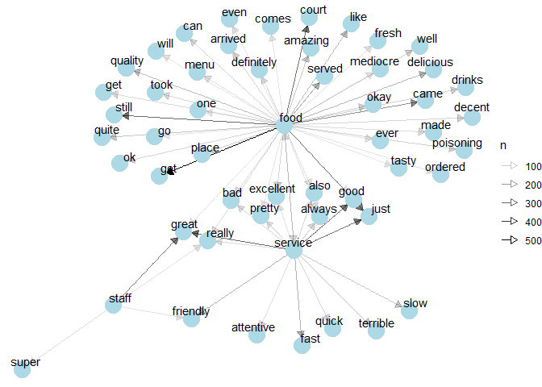

```r
review2  <- review %>%
           filter(business_id %in% business$business_id )

useful <-     review2 %>%
              left_join(business, by = "business_id") %>%
              # Filters reviews for Toronto
              filter(city == 'Toronto', is_open == 0) %>%
              # Only reviews that atleast 2 people found as useful is taken
              filter(useful > 1)

# All text is converted to lower case
useful$text <- tolower(useful$text)
# Stop words and repeating words like Las vegas, http, www.yelp.com are removed
useful$text <- removeWords(useful$text ,c(stopwords("en")))
useful$text <- removeNumbers(useful$text)

# Bigrams are created with words in review text
bigrams <- useful %>%
           unnest_tokens(bigram, text, token = "ngrams", n = 2)

# List of words that are of significance
analysis_word <- c("food", "service", "staff", "ambience")

# Creates data for network analysis graph
bg_grapgh <- bigrams %>%
             # Words from bigram are seperated
             separate(bigram, c("word1", "word2"), sep = " ")  %>%
             # Count for each combination of words are calculated
             group_by(word1, word2) %>%
             summarise( n = n()) %>%
             # Only the combination with significant words in the beginning and min freq of 50 are taken
             filter( word1 %in% analysis_word & n > 50) %>%
             # Creates data for network graph
             graph_from_data_frame()

arrow_format <- grid::arrow(type = "closed", length = unit(.1, "inches"))

## Visual representation of connection of pair of words
ggraph(bg_grapgh, layout = "fr") +
  # Connection between words are represented by arrows
  geom_edge_link(aes(edge_alpha = n),
                 show.legend = TRUE,
                 arrow = arrow_format,
                 end_cap = circle(.1, 'inches')) +
  # Nodes for words
  geom_node_point(color = 'light blue',
                  size = 7) +
  # Text is displayed
  geom_node_text(aes(label = name),
                 vjust = 1,
                 hjust = 1,
                 repel = TRUE) +
  theme_void()
```

### Wordcloud for the reviews of “Watermark Irish Pub”

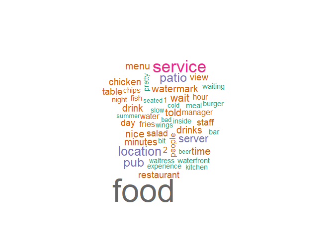

```r
#Toula Restaurant & Bar
createWordCloud(review %>%
  filter(business_id == "JgaQFKxW-Bnfc7r5EJZhSQ"))
```

### Sentiment Analysis - Postive and Not So Postive Words of “Watermark Irish Pub”

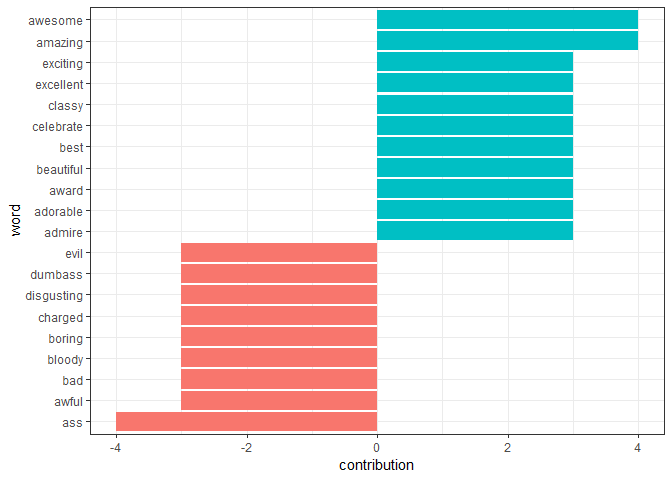

```r
positiveWordsBarGraph <- function(SC) {
  contributions <- SC %>%
    unnest_tokens(word, text) %>%
    count(word,sort = TRUE) %>%
    ungroup() %>%

    inner_join(get_sentiments("afinn"), by = "word") %>%
    group_by(word) %>%
    summarize(occurences = n(),
              contribution = sum(score))

  contributions %>%
    top_n(20, abs(contribution)) %>%
    mutate(word = reorder(word, contribution)) %>%
    head(20) %>%
    ggplot(aes(word, contribution, fill = contribution > 0)) +
    geom_col(show.legend = FALSE) +
    coord_flip() + theme_bw()
}

positiveWordsBarGraph(review %>%
                        filter(business_id == "JgaQFKxW-Bnfc7r5EJZhSQ"))
```

### Let’s examine the top 5 most negative reviews.

service was subpar, The hostesses at the patio were incredibly rude, The service was horrendous, Worst veggie burger, Terrible service

```r
Watermark_Irish_Pub = review %>%
  filter(business_id == "JgaQFKxW-Bnfc7r5EJZhSQ")

sentiment_lines = calculate_sentiment(Watermark_Irish_Pub)
display_neg_sentiments(sentiment_lines ,Watermark_Irish_Pub)
```

```
## [1] "The location is great, that's about it. Right from the moment we got there, the service was subpar. The hostesses at the patio were incredibly rude and argued with us over empty tables. I can see them there empty, stop telling me they are full. We eventually got seated inside, by the patio, …
## [2] "I wanted to like this place. Nice location. A large summer patio. Might be cozy in winter. \n\nThe Australian and I came here seeking food and some air conditioning. It was a humid day out and didn't feel like sitting on the patio. It was a first date kinda thing and we requested a booth for…
## [3] "Was there on Thursday for a large group over the lunch hour. (Yes we reserved and had a set menu, so they should have been prepared.)\n\nAfter waiting 2 hours for a meal to arrive I had to leave without lunch. The service was horrendous and from those that remained I'm told the food was no b…
## [4] "Worst veggie burger I've had in my entire life.  Only offering one vegetarian option is fine.  I'm used to going out and have only a veggie burger to choose from but it needs to be at least edible.  This was the most embarrassing excuse for a veggie burger that I have ever seen.  For 14$ I'd…
## [5] "Terrible service; mediocre food; terrible service, expensive 14oz \"\"pints\"\"; terrible service; not a great beer selection; slow; grumpy staff; beautiful outdoor patio; terrible service; does not take outdoor reservations; pricey; terrible service.\n\nI work in the same building so we gav…
```

### Further steps.

- Create a machine learning model that will identify if the restaurant is open or closed
- Predict the rating that customer might give to a restaurant by analysing the review given by him/her.